# Hordan

# load data

```r
library(ggplot2)
library(psych)
library(car)
library(FactoMineR)
library(corrgram)
library(tidyverse)
library(stringr)
Master_Zipper_gud <- read_csv("Property Value/Master_Zipper_gud.csv", col_types = cols(SaleDate = col_date(format = "%m/%d/%Y")))
```

What does the data look like? Switch some Variable types

```r
#Master_Zipper_gud$Type <- factor(Master_Zipper_gud$Type)
#Master_Zipper_gud$Age <- is.factor(Master_Zipper_gud$Age)
#Master_Zipper_gud$BuildingCondition <- is.factor(Master_Zipper_gud$BuildingCondition)
#Master_Zipper_gud$BuildingClass <- is.factor(Master_Zipper_gud$BuildingClass)
#Master_Zipper_gud$BuildingMaterials <- is.factor(Master_Zipper_gud$BuildingMaterials)
#Master_Zipper_gud$Floors <- is.factor(Master_Zipper_gud$Floors)
#Master_Zipper_gud$ZipCode <- is.factor(Master_Zipper_gud$ZipCode)
#Master_Zipper_gud$Zoning <- is.factor(Master_Zipper_gud$Zoning)
#Master_Zipper_gud$Rating <- as.ordered(Master_Zipper_gud$Rating)
#Master_Zipper_gud$SaleCondition <- is.factor(Master_Zipper_gud$SaleCondition)
#Master_Zipper_gud$YearBuilt <- is.factor(Master_Zipper_gud$YearBuilt)
head(Master_Zipper_gud)
```

| Address | Type | SaleDate | SalePrice | GRM | Cap | PricePerSF | PricePerUnit | BldgSF | NumberOfUnits | Age | BuildingCondition | BuildingClass | BuildingMaterials | Latitude | Longitude | 1Bedrooms | 2Bedrooms | 3Bedrooms | Floors | ZipCode | Rating | Vacancy | Zoning | SaleCondition | YearBuilt |
| --- | --- | --- | --- | --- | --- | --- | --- | --- | --- | --- | --- | --- | --- | --- | --- | --- | --- | --- | --- | --- | --- | --- | --- | --- | --- |
| 3400 Richmond Pky | Multi-Family | 2005-05-11 | 114500000 | NA | 5.89 | 128.33 | 113591 | 892224 | 1008 | 30 | Good | A | Steel | 37.98587 | -122.3261 | 481 | 527 | 0 | 4 | 94806 | 3 Star | 0 | N/Av | 1031 Exchange | 1987 |
| 3400 Richmond Pky | Multi-Family | 2011-06-01 | 140500000 | NA | 6.12 | 157.47 | 139385 | 892224 | 1008 | 30 | Good | A | Steel | 37.98587 | -122.3261 | 480 | 528 | 0 | 4 | 94806 | 3 Star | 0 | N/Av | NA | 1987 |
| 4170 Springlake Dr | Multi-Family | 2011-10-28 | 110000000 | NA | 5.50 | 179.57 | 130952 | 612576 | 840 | 45 | Good | C | Wood | 37.69316 | -122.1333 | 456 | 176 | 0 | 2 | 94578 | 2 Star | 0 | RM-1800 | NA | 1972 |
| 1001-1101 Park Pl (Part of Portfolio) | Multi-Family | 2013-02-27 | NA | NA | NA | NA | NA | 520000 | 575 | 14 | Good | B | ReinforcedConcrete | 37.54595 | -122.2912 | 306 | 231 | 38 | 3 | 94403 | 4 Star | 0 | N/Av | Bulk/Portfolio Sale | 2003 |
| 39600 Fremont Blvd | Multi-Family | 2000-05-02 | 55000000 | NA | 7.42 | 127.23 | 104563 | 432290 | 526 | 42 | Good | C | Wood | 37.54591 | -121.9788 | 300 | 0 | 0 | 3 | 94538 | 2 Star | 0 | RGX13.78 | NA | 1975 |
| 1-249 Marina Lakes Dr | Multi-Family | 2004-12-21 | 98500000 | NA | 3.96 | 247.31 | 210470 | 398292 | 468 | 25 | Good | A | Wood | 37.91317 | -122.3428 | 252 | 216 | 0 | 3 | 94804 | 4 Star | 0 | PA | Condo Conversion | 1992 |

```r
summary(Master_Zipper_gud)
```

```
   Address              Type              SaleDate            SalePrice              GRM             Cap
 Length:9660        Length:9660        Min.   :1989-11-03   Min.   :        0   Min.   : 2.04   Min.   : 1.000
 Class :character   Class :character   1st Qu.:2002-12-17   1st Qu.:   890000   1st Qu.: 9.30   1st Qu.: 4.700
 Mode  :character   Mode  :character   Median :2007-05-31   Median :  1600000   Median :11.38   Median : 5.750
                                       Mean   :2008-01-12   Mean   :  6428669   Mean   :11.80   Mean   : 5.981
                                       3rd Qu.:2013-07-03   3rd Qu.:  3450000   3rd Qu.:13.87   3rd Qu.: 7.000
                                       Max.   :2017-03-20   Max.   :864500000   Max.   :37.00   Max.   :26.100
                                       NA's   :42           NA's   :466         NA's   :5147    NA's   :1632
   PricePerSF       PricePerUnit         BldgSF        NumberOfUnits          Age        BuildingCondition
 Min.   :      0   Min.   :      0   Min.   :      1   Min.   :   0.00   Min.   :  1.0   Length:9660
 1st Qu.:    132   1st Qu.: 102584   1st Qu.:   4568   1st Qu.:   6.00   1st Qu.: 50.0   Class :character
 Median :    202   Median : 148500   Median :   7910   Median :   8.00   Median : 62.0   Mode  :character
 Mean   :    967   Mean   : 185676   Mean   :  26242   Mean   :  20.02   Mean   : 70.3
 3rd Qu.:    304   3rd Qu.: 226779   3rd Qu.:  17700   3rd Qu.:  16.00   3rd Qu.: 98.0
 Max.   :6650000   Max.   :3750000   Max.   :1355370   Max.   :1008.00   Max.   :164.0
 NA's   :427       NA's   :3465      NA's   :6         NA's   :3499      NA's   :206
 BuildingClass      BuildingMaterials     Latitude       Longitude        1Bedrooms        2Bedrooms
 Length:9660        Length:9660        Min.   :37.30   Min.   :-122.6   Min.   :  0.00   Min.   :  0.000
 Class :character   Class :character   1st Qu.:37.75   1st Qu.:-122.4   1st Qu.:  0.00   1st Qu.:  0.000
 Mode  :character   Mode  :character   Median :37.78   Median :-122.3   Median :  3.00   Median :  2.000
                                       Mean   :37.78   Mean   :-122.3   Mean   :  8.37   Mean   :  6.639
                                       3rd Qu.:37.82   3rd Qu.:-122.2   3rd Qu.:  8.00   3rd Qu.:  6.000
                                       Max.   :38.53   Max.   :-121.7   Max.   :481.00   Max.   :528.000
                                       NA's   :3       NA's   :3        NA's   :3514     NA's   :3514
   3Bedrooms           Floors          ZipCode         Rating             Vacancy          Zoning
 Min.   :  0.000   Min.   : 1.000   Min.   :94102   Length:9660        Min.   :  0.00   Length:9660
 1st Qu.:  0.000   1st Qu.: 2.000   1st Qu.:94117   Class :character   1st Qu.:  0.00   Class :character
 Median :  0.000   Median : 2.000   Median :94544   Mode  :character   Median :  0.00   Mode  :character
 Mean   :  0.786   Mean   : 2.708   Mean   :94441                      Mean   :  1.79
 3rd Qu.:  0.000   3rd Qu.: 3.000   3rd Qu.:94608                      3rd Qu.:  0.00
 Max.   :196.000   Max.   :52.000   Max.   :95128                      Max.   :100.00
 NA's   :3514      NA's   :202
 SaleCondition        YearBuilt
 Length:9660        Min.   :1853
 Class :character   1st Qu.:1919
 Mode  :character   Median :1955
                    Mean   :1947
                    3rd Qu.:1967
                    Max.   :2016
                    NA's   :206
```

# Cleaning

Removing NAs, and giving correct data where NA is inappropiate. Switch some Variable types

```r
Bay_Area <- Master_Zipper_gud %>%
  filter(!is.na(Address) & !is.na(Type) & !is.na(SaleDate) & !is.na(SalePrice) & !is.na(GRM) & !is.na(Cap) & !is.na(PricePerSF) & !is.na(PricePerUnit) & !is.na(BldgSF) & !is.na(NumberOfUnits) & !is.na(Age) & !is.na(BuildingCondition) & !is.na(BuildingClass) & !is.na(BuildingMaterials) & !is.na(Latitude) & !is.na(Longitude) & !is.na(Floors) & !is.na(ZipCode) & !is.na(Rating) & !is.na(Vacancy) & !is.na(Zoning) & !is.na(SaleCondition) & !is.na(YearBuilt))
```

Lets look at the difference without NAs

```r
dim(Master_Zipper_gud)[1]
```

```
[1] 9660
```

```r
dim(Bay_Area)[1]
```

```
[1] 1439
```

# Data Exploration

Vacancy, NumberOfUnits, Floors need to be changed to factor/char/ordered/nominal

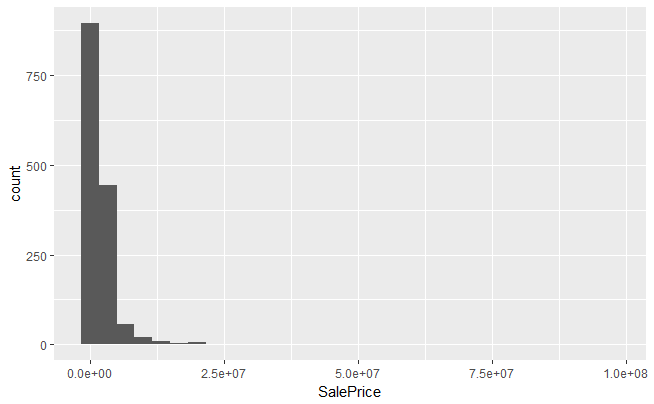

```r
Bay_Area %>%
  ggplot(aes(x = SalePrice)) +
  geom_histogram()
```

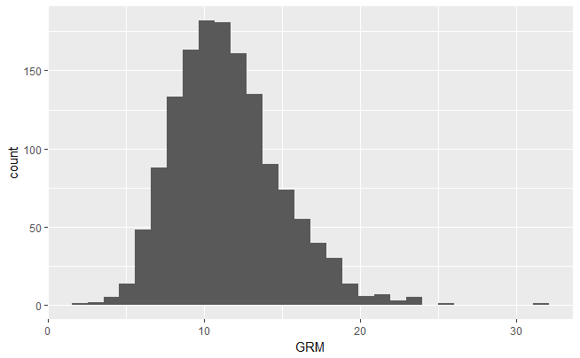

```r
Bay_Area %>%
  ggplot(aes(x = GRM)) +
  geom_histogram()
```

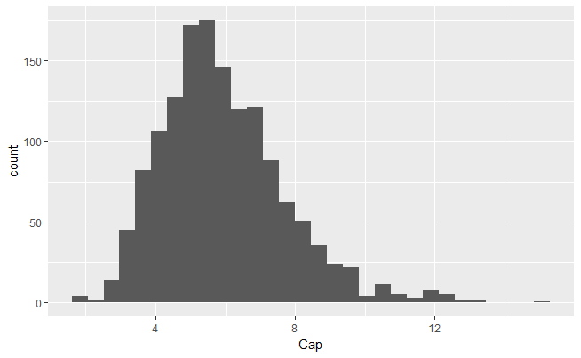

```r
Bay_Area %>%
  ggplot(aes(x = Cap)) +
  geom_histogram()
```

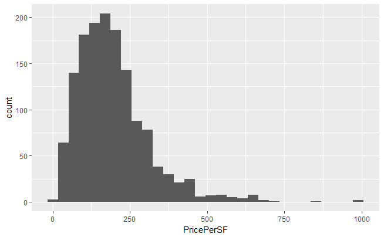

```r
Bay_Area %>%
  ggplot(aes(x = PricePerSF)) +
  geom_histogram()
```

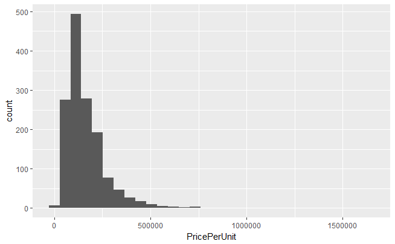

```r
Bay_Area %>%
  ggplot(aes(x = PricePerUnit)) +
  geom_histogram()
```

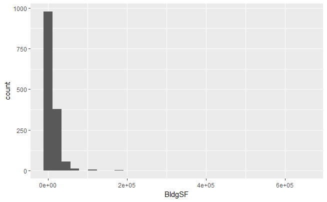

```r
Bay_Area %>%
  ggplot(aes(x = BldgSF)) +
  geom_histogram()
```

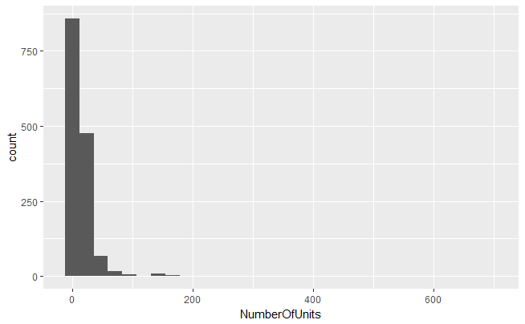

```r
Bay_Area %>%
  ggplot(aes(x = NumberOfUnits)) +
  geom_histogram()
```

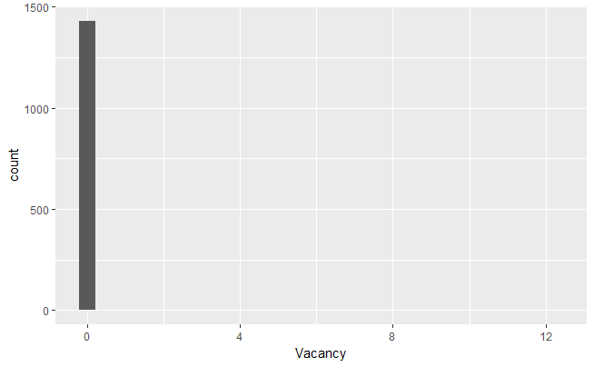

```r
Bay_Area %>%
  ggplot(aes(x = Vacancy)) +
  geom_histogram()
```

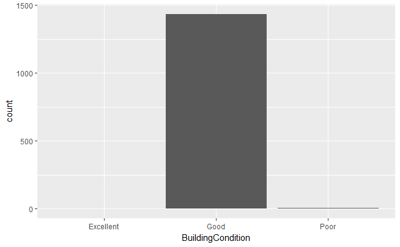

```r
Bay_Area %>%
  ggplot(aes(x = BuildingCondition)) +
  geom_bar()
```

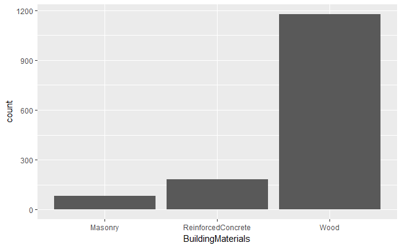

```r
Bay_Area %>%
  ggplot(aes(x = BuildingMaterials)) +
  geom_bar()
```

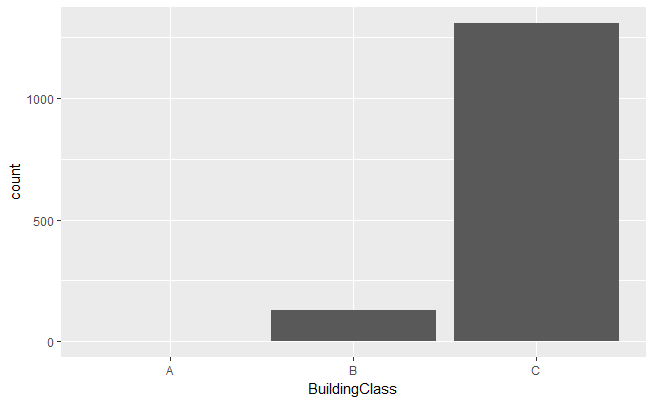

```r
Bay_Area %>%
  ggplot(aes(x = BuildingClass)) +
  geom_bar()
```

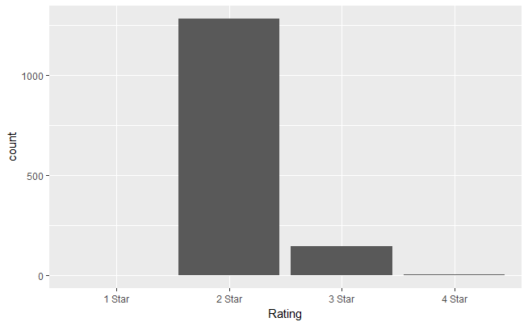

```r
Bay_Area %>%
  ggplot(aes(x = Rating)) +
  geom_bar()
```

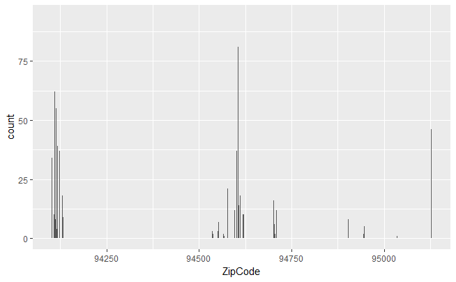

```r
Bay_Area %>%
  ggplot(aes(x = ZipCode)) +
  geom_bar()
```

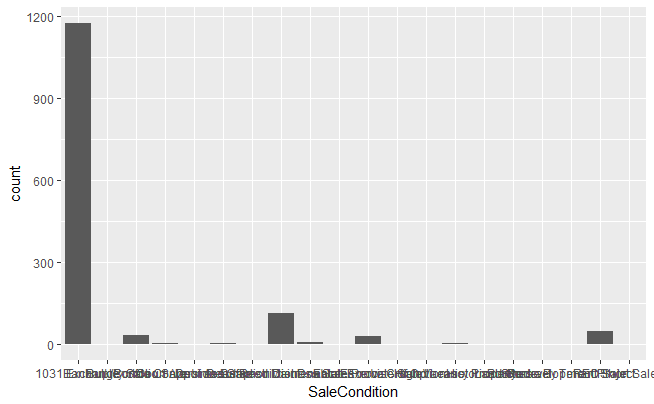

```r
Bay_Area %>%
  ggplot(aes(x = SaleCondition)) +
  geom_bar()
```

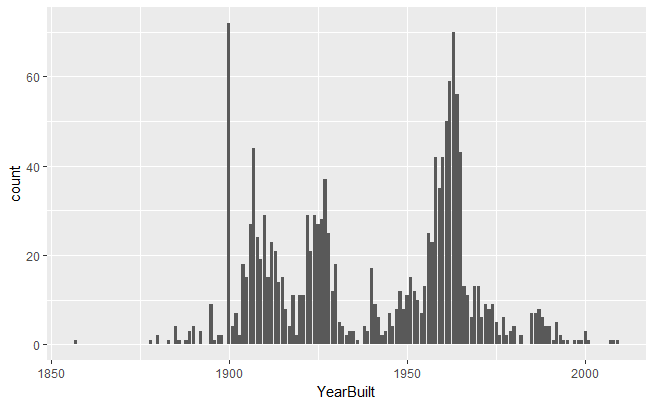

```r
Bay_Area %>%
  ggplot(aes(x = YearBuilt)) +
  geom_bar()
```

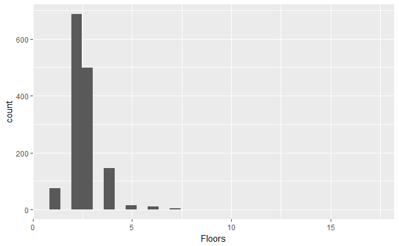

```r
Bay_Area %>%
  ggplot(aes(x = Floors)) +
  geom_histogram()
```

A few of these variable might need to be discarded, and some will need transformation (most like nature log) discard:vacancy Transform:Price,p/sq, p/u, BldgSF, num of units, Age (parabola?), floors

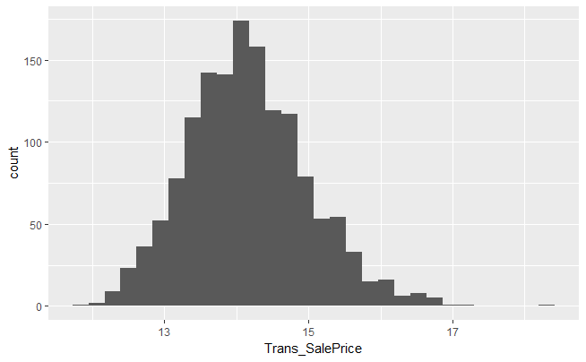

```r
Bay_Area['Trans_SalePrice'] <- NA
Bay_Area['Trans_PricePerSF'] <- NA
Bay_Area['Trans_PricePerUnit'] <- NA
Bay_Area['Trans_BldgSF'] <- NA
Bay_Area['Trans_NumberOfUnits'] <- NA
Bay_Area['Trans_Floors'] <- NA
Bay_Area$Trans_SalePrice <- log(Bay_Area$SalePrice)
Bay_Area$Trans_PricePerSF <- log(Bay_Area$PricePerSF)
Bay_Area$Trans_PricePerUnit <- log(Bay_Area$PricePerUnit)
Bay_Area$Trans_BldgSF <- log(Bay_Area$BldgSF)
Bay_Area$Trans_NumberOfUnits <- log(log(Bay_Area$NumberOfUnits))
Bay_Area$Trans_Floors <- log(Bay_Area$Floors)
Bay_Area %>%
  ggplot(aes(x = Trans_SalePrice)) +
  geom_histogram()
```

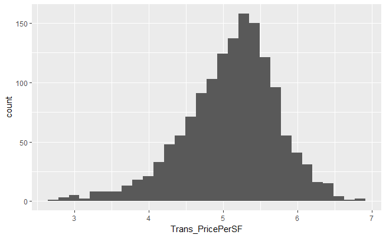

```r
Bay_Area %>%
  ggplot(aes(x = Trans_PricePerSF)) +
  geom_histogram()
```

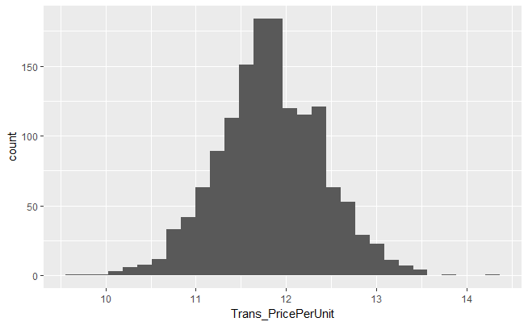

```r
Bay_Area %>%
  ggplot(aes(x = Trans_PricePerUnit)) +
  geom_histogram()
```

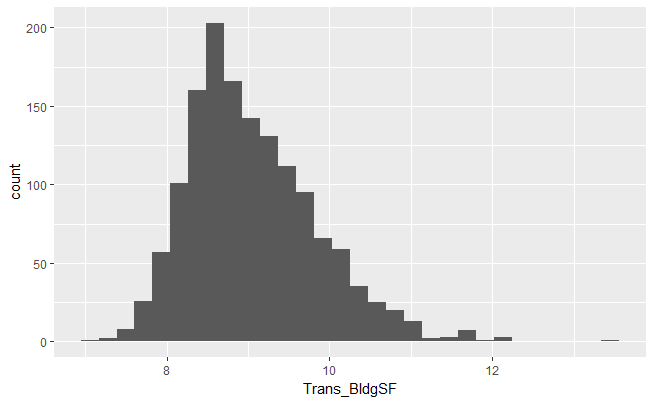

```r
Bay_Area %>%
  ggplot(aes(x = Trans_BldgSF)) +
  geom_histogram()
```

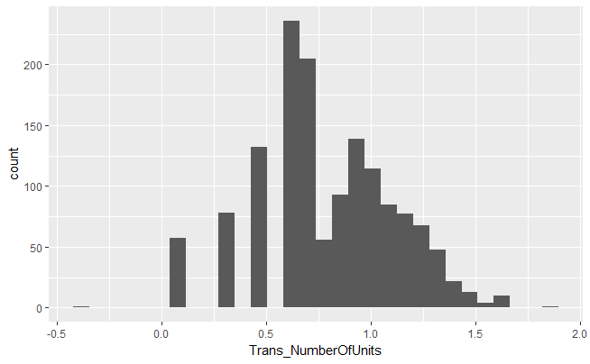

```r
Bay_Area %>%
  ggplot(aes(x = Trans_NumberOfUnits)) +
  geom_histogram()
```

### With Sale Price as the dependent variable,

### How correlated are the independent variables to it?

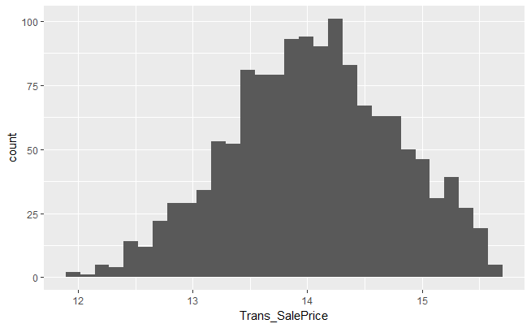

```r
Bay_Area <- Bay_Area[Bay_Area$Trans_SalePrice < quantile(Bay_Area$Trans_SalePrice, 0.95), ]
Bay_Area %>%
  ggplot(aes(x = Trans_SalePrice)) +
  geom_histogram()
```

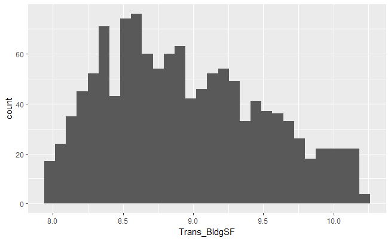

```r
Bay_Area <- Bay_Area[Bay_Area$Trans_BldgSF < quantile(Bay_Area$Trans_BldgSF, 0.95), ]
Bay_Area <- Bay_Area[Bay_Area$Trans_BldgSF > quantile(Bay_Area$Trans_BldgSF, 0.05), ]
Bay_Area %>%
  ggplot(aes(x = Trans_BldgSF)) +
  geom_histogram()
```

Remove Large NA columns for correlation graph

```r
sapply(Bay_Area, is.numeric)
```

```
            Address                Type            SaleDate           SalePrice                 GRM
              FALSE               FALSE               FALSE                TRUE                TRUE
                Cap          PricePerSF        PricePerUnit              BldgSF       NumberOfUnits
               TRUE                TRUE                TRUE                TRUE                TRUE
                Age   BuildingCondition       BuildingClass   BuildingMaterials            Latitude
               TRUE               FALSE               FALSE               FALSE                TRUE
          Longitude           1Bedrooms           2Bedrooms           3Bedrooms              Floors
               TRUE                TRUE                TRUE                TRUE                TRUE
            ZipCode              Rating             Vacancy              Zoning       SaleCondition
               TRUE               FALSE                TRUE               FALSE               FALSE
          YearBuilt     Trans_SalePrice    Trans_PricePerSF  Trans_PricePerUnit        Trans_BldgSF
               TRUE                TRUE                TRUE                TRUE                TRUE
Trans_NumberOfUnits        Trans_Floors
               TRUE                TRUE
```

```r
View(Bay_Area)
cor_BA <- cbind.data.frame(Bay_Area$Trans_SalePrice, Bay_Area$Trans_BldgSF, Bay_Area$Trans_NumberOfUnits, Bay_Area$GRM, Bay_Area$Cap)
```

# Regression Models

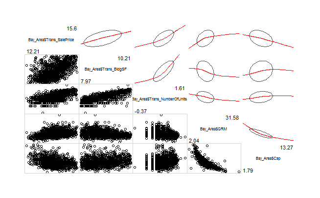

```r
corrgram(x = cor_BA, type = 'data', order= FALSE, lower.panel=panel.pts,
  upper.panel=panel.ellipse, text.panel=panel.txt,
  diag.panel=panel.minmax)
```

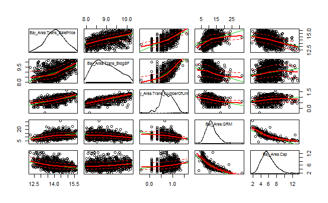

```r
scatterplotMatrix(cor_BA)
```

Number of Units and GRM/Cap/Age is abnormal because NoU is actually cateogical

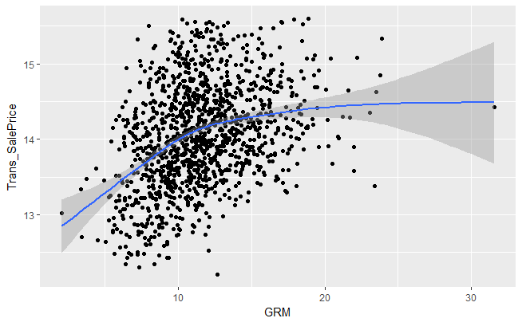

```r
Bay_Area %>%
  ggplot(aes(x = GRM, y = Trans_SalePrice)) +
  geom_point() +
  geom_smooth()
```

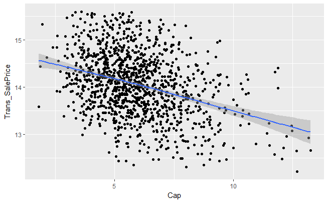

```r
Bay_Area %>%
  ggplot(aes(x = Cap, y = Trans_SalePrice)) +
  geom_point() +
  geom_smooth()
```

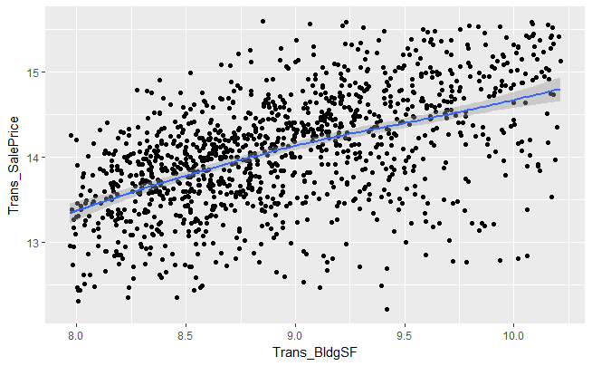

```r
Bay_Area %>%
  ggplot(aes(x = Trans_BldgSF, y = Trans_SalePrice)) +
  geom_point() +
  geom_smooth()
```

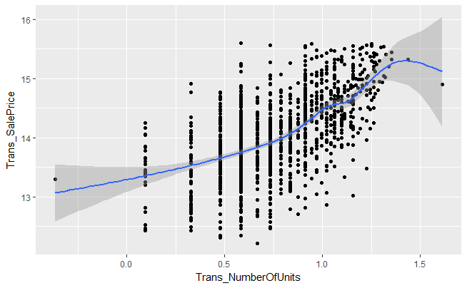

```r
Bay_Area %>%
  ggplot(aes(x = Trans_NumberOfUnits, y = Trans_SalePrice)) +
  geom_point() +
  geom_smooth()
```

```r
sapply(Bay_Area, is.character)
```

```
            Address                Type            SaleDate           SalePrice                 GRM
               TRUE                TRUE               FALSE               FALSE               FALSE
                Cap          PricePerSF        PricePerUnit              BldgSF       NumberOfUnits
              FALSE               FALSE               FALSE               FALSE               FALSE
                Age   BuildingCondition       BuildingClass   BuildingMaterials            Latitude
              FALSE                TRUE                TRUE                TRUE               FALSE
          Longitude           1Bedrooms           2Bedrooms           3Bedrooms              Floors
              FALSE               FALSE               FALSE               FALSE               FALSE
            ZipCode              Rating             Vacancy              Zoning       SaleCondition
              FALSE                TRUE               FALSE                TRUE                TRUE
          YearBuilt     Trans_SalePrice    Trans_PricePerSF  Trans_PricePerUnit        Trans_BldgSF
              FALSE               FALSE               FALSE               FALSE               FALSE
Trans_NumberOfUnits        Trans_Floors
              FALSE               FALSE
```

```r
unique(Bay_Area$ZipCode)
```

```
 [1] 94102 94578 94601 94596 94536 95128 94621 94558 94903 94610 94501 94605 94609 94110 94118 94114 94541 94122
[19] 94806 94703 94702 94709 94131 94606 94612 94520 94804 94109 94544 94553 94602 94115 94509 94108 94619 94705
[37] 94117 94901 94611 94577 94608 94603 94539 94103 94123 94121 94112 94618 94133 94116 94403 94134 94560 94565
[55] 94947 94704 94607 94801 94566 94710 94706 94107 94551 94550 94546 95035
```